# Understanding Student Depression

### Fitting Finalized Models

- As mentioned before, I will only fit my two best performing models, the Logistic Regression and the Boosted Tree model. This will involve finalizing the workflow for the Boosted model by updating it with the best hyperparameter configuration, which was derived from our grid tuning process, before I can fit it to my full training data set. This process is not necessary for the Logistic Regression model and I can immediately fit it to my training set without any intermediary steps

```r
final_boosted_wf = finalize_workflow(boosted_wf, best_boosted)
boosted_fit = fit(final_boosted_wf, depression_train)
log_fit = fit(log_wf, depression_train)
```

- I am interested now in understanding which predictor variables were most important in making classification decisions. As mentioned earlier throughout this analysis, I have made many guesses on which variables would be of highest important, such as sleep habits, dietary habits, and academic pressure. Since the Boosted Tree model automatically stores variable importance information with the `xgboost` package, we are able to quite easily perform this analysis.

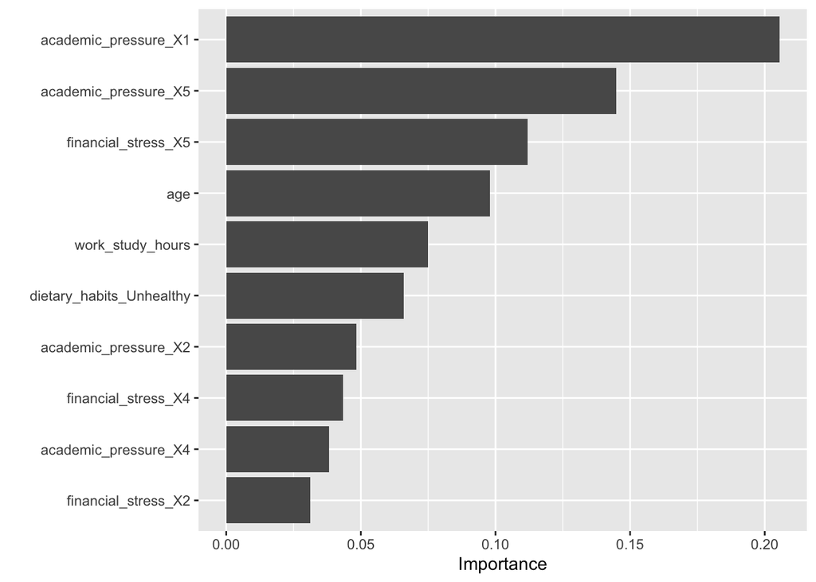

```r
boosted_fit %>% extract_fit_parsnip() %>%
  vip()
```

- Score!! I was right about `academic_pressure` being one of the most important predictor variables to decide if a student will be depressed or not. The other important covariates that we can observe here are `financial_stress`, `dietary_habits`, `age`, and `work_study hours`. Surprisingly, `sleep_duration` here does not show up as a very important predictor. This is truly very fascinating to me as it appeared in my exploratory data analysis step that there was a huge proportional difference in depression based on `sleep_duration`. Oh well, I am not entirely disappointed since we see so many interesting effects here! These variables shown here are the most important in making decisions in our Boosted tree model, not the Logistic Regression model.
- Another surprising aspect of this plot is that `age` was an important predictor in making classification decisions in the Boosted tree model. I did not anticipate age being an important predictor at all throughout this analysis, and did not include it in any of my exploratory data analysis. I am grateful that these models are more intuitive than myself in figuring out which predictors are the most important! I would have easily missed this effect otherwise.
- Out of sheer curiosity, I would like to understand the effect of age on depression prevalence among these students. I will use EDA again to visualize what is going on here.

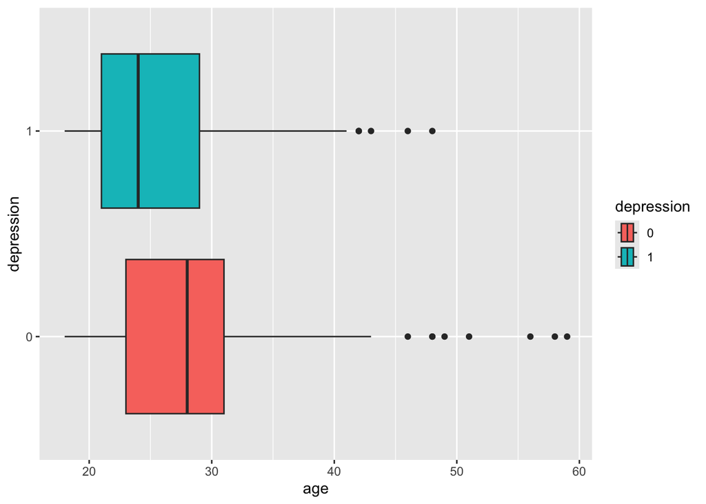

```r
depression_train %>% ggplot(aes(x=age, y=depression, fill=depression)) + geom_boxplot()
```

- It appears that younger students tend to be depressed more than older students in this data. Most of the depressed students seem to be in their early to mid 20’s while most of the non-depressed students seem to be in their mid to late 20’s. This is an interesting finding that I will discuss in more detail later on in this analysis, but my initial reaction to this is that it fits with our overall narrative that depression is becoming a more prevalent issue among the newer generations of students.